# Sequential Models in NLP: Sentiment Classification

## George Mathew

Task is to predict the sentiment (Positive or Negative) of the reviews given to some movies in the IMDB dataset.

# Sentiment Classification

### Dataset

- Dataset of 50,000 movie reviews from IMDB, labeled by sentiment positive (1) or negative (0)
- Reviews have been preprocessed, and each review is encoded as a sequence of word indexes (integers).
- For convenience, words are indexed by overall frequency in the dataset, so that for instance the integer "3" encodes the 3rd most frequent word in the data. This allows for quick filtering operations such as: "only consider the top 10,000 most common words, but eliminate the top 20 most common words".
- As a convention, "0" does not stand for a specific word, but instead is used to encode any unknown word.

Command to import data

- `from tensorflow.keras.datasets import imdb`

```python
from keras.datasets import imdb
from keras.models import Sequential
from keras.layers import Dense
from keras.layers import LSTM, Flatten, Dropout, TimeDistributed
from keras.layers.embeddings import Embedding
from keras.preprocessing import sequence
import matplotlib.pyplot as plt
import numpy
import seaborn as sns
```

### Import the data (4 Marks)

- Use `imdb.load_data()` method
- Get train and test set
- Take 10000 most frequent words

```python
#### Add your code here ####
(X_train, y_train), (X_test, y_test) = imdb.load_data(num_words=10018, skip_top=20)
```

### Pad each sentence to be of same length (4 Marks)

- Take maximum sequence length as 300

```python
#### Add your code here ####
max_review_length = 300
X_train = sequence.pad_sequences(X_train, maxlen=max_review_length)
X_test = sequence.pad_sequences(X_test, maxlen=max_review_length)
```

```python
X_train[:1]
```

```
array([[   0,    0,    0,    0,    0,    0,    0,    0,    0,    0,    0,
           0,    0,    0,    0,    0,    0,    0,    0,    0,    0,    0,
           0,    0,    0,    0,    0,    0,    0,    0,    0,    0,    0,
           0,    0,    0,    0,    0,    0,    0,    0,    0,    0,    0,
           0,    0,    0,    0,    0,    0,    0,    0,    0,    0,    0,
           0,    0,    0,    0,    0,    0,    0,    0,    0,    0,    0,
           0,    0,    0,    0,    0,    0,    0,    0,    0,    0,    0,
           0,    0,    0,    0,    0,    2,    2,   22,    2,   43,  530,
         973, 1622, 1385,   65,  458, 4468,   66, 3941,    2,  173,   36,
         256,    2,   25,  100,   43,  838,  112,   50,  670,    2,    2,
          35,  480,  284,    2,  150,    2,  172,  112,  167,    2,  336,
         385,   39,    2,  172, 4536, 1111,    2,  546,   38,    2,  447,
           2,  192,   50,    2,    2,  147, 2025,    2,    2,   22,    2,
        1920, 4613,  469,    2,   22,   71,   87,    2,    2,   43,  530,
          38,   76,    2,    2, 1247,    2,   22,    2,  515,    2,    2,
           2,  626,    2,    2,    2,   62,  386,    2,    2,  316,    2,
         106,    2,    2, 2223, 5244,    2,  480,   66, 3785,   33,    2,
         130,    2,    2,   38,  619,    2,   25,  124,   51,   36,  135,
          48,   25, 1415,   33,    2,   22,    2,  215,   28,   77,   52,
           2,    2,  407,    2,   82,    2,    2,    2,  107,  117, 5952,
           2,  256,    2,    2,    2, 3766,    2,  723,   36,   71,   43,
         530,  476,   26,  400,  317,   46,    2,    2,    2, 1029,    2,
         104,   88,    2,  381,    2,  297,   98,   32, 2071,   56,   26,
         141,    2,  194, 7486,    2,    2,  226,   22,   21,  134,  476,
          26,  480,    2,  144,   30, 5535,    2,   51,   36,   28,  224,
          92,   25,  104,    2,  226,   65,    2,   38, 1334,   88,    2,
           2,  283,    2,    2, 4472,  113,  103,   32,    2,    2, 5345,
           2,  178,   32]])
```

```python
print("Train Review length: ")
result = [len(x) for x in X_train]
print("Mean %.2f words (%f)" % (numpy.mean(result), numpy.std(result)))
print("Test Review length: ")
result = [len(x) for x in X_test]
print("Mean %.2f words (%f)" % (numpy.mean(result), numpy.std(result)))
```

```
Train Review length:
Mean 300.00 words (0.000000)
Test Review length:
Mean 300.00 words (0.000000)
```

```python
print("Shape of X_train is ", X_train.shape)
print("Shape of y_train is ", y_train.shape)
print("Shape of X_test is ", X_test.shape)
print("Shape of y_test is ", y_test.shape)
```

```
Shape of X_train is  (25000, 300)
Shape of y_train is  (25000,)
Shape of X_test is  (25000, 300)
Shape of y_test is  (25000,)
```

### Print shape of features & labels (4 Marks)

Number of review, number of words in each review

```python
#### Add your code here ####
shape = X_train.shape

print("Number of reviews is ", shape[0])
```

```
Number of reviews is  25000
```

```python
#### Add your code here ####
print("Number of words per review is ", shape[1])
```

```
Number of words per review is  300
```

Number of labels

```python
#### Add your code here ####
print("Classes: ")
print(numpy.unique(y_train))
```

```
Classes:
[0 1]
```

```python
#### Add your code here ####
print("Number of words: ")
print(len(numpy.unique(numpy.hstack(X_train))))
```

```
Number of words:
10000
```

### Print value of any one feature and it's label (4 Marks)

Feature value

```python
#### Add your code here ####
index = imdb.get_word_index()
print(len(index))
```

```
88584
```

```python
reverse_index = dict([(value, key) for (key, value) in index.items()])
print(reverse_index.get(34701))
```

```
fawn
```

Label value

```python
#### Add your code here ####
reverse_index = dict([(key, value) for (key, value) in index.items()])
print(reverse_index.get('fawn'))
```

```
34701
```

### Decode the feature value to get original sentence (4 Marks)

First, retrieve a dictionary that contains mapping of words to their index in the IMDB dataset

```python
#### Add your code here ####
index = imdb.get_word_index()
print(index)
```

[output not shown]

Now use the dictionary to get the original words from the encodings, for a particular sentence

```python
#### Add your code here ####
reverse_index = dict([(value, key) for (key, value) in index.items()])
decoded = " ".join( [reverse_index.get(i, "#") for i in X_train[0]] )
print(decoded)
```

```
# # # # # # # # # # # # # # # # # # # # # # # # # # # # # # # # # # # # # # # # # # # # # # # # # # # # # # # # # # # # # # # # # # # # # # # # # # # # # # # # # # and and you and out themselves powerful lets loves their becomes reaching had journalist and lot from anyone and have after out atmosphe…
```

Get the sentiment for the above sentence

- positive (1)
- negative (0)

```python
#### Add your code here ####
sentiment = y_train[0]
if sentiment == 1:
    print('Positive Review')
else:
    print('Negative Review')
```

```
Positive Review
```

### Define model (10 Marks)

```python
#### Add your code here ####

vocab_size = 25000

model = Sequential()
embedding_layer = Embedding(vocab_size, 100, input_length=300)
model.add(embedding_layer)
model.add(LSTM(100, dropout=0.2, recurrent_dropout=0.2, return_sequences=True))
model.add(TimeDistributed(Dense(100, activation='relu')))
model.add(Dropout(0.2))
model.add(Flatten())
model.add(Dense(1, activation='sigmoid'))
```

### Compile the model (4 Marks)

- Use Optimizer as Adam
- Use Binary Crossentropy as loss
- Use Accuracy as metrics

```python
#### Add your code here ####
model.compile(loss='binary_crossentropy',
              optimizer='adam',
              metrics=['accuracy'])
```

### Print model summary (4 Marks)

```python
#### Add your code here ####
model.summary()
```

```
Model: "sequential_1"
_________________________________________________________________
Layer (type)                 Output Shape              Param #
=================================================================
embedding_1 (Embedding)      (None, 300, 100)          2500000
_________________________________________________________________
lstm_1 (LSTM)                (None, 300, 100)          80400
_________________________________________________________________
time_distributed_1 (TimeDist (None, 300, 100)          10100
_________________________________________________________________
dropout_1 (Dropout)          (None, 300, 100)          0
_________________________________________________________________
flatten_1 (Flatten)          (None, 30000)             0
_________________________________________________________________
dense_2 (Dense)              (None, 1)                 30001
=================================================================
Total params: 2,620,501
Trainable params: 2,620,501
Non-trainable params: 0
_________________________________________________________________
```

### Fit the model (4 Marks)

```python
#### Add your code here ####
history = model.fit(X_train, y_train, batch_size=200, epochs=5, verbose=1, validation_split=0.2)
```

```
Train on 20000 samples, validate on 5000 samples
```

### Evaluate model (4 Marks)

```python
scores = model.evaluate(X_test, y_test, verbose=1)
```

```python
scores[1]
```

```
0.8583199977874756
```

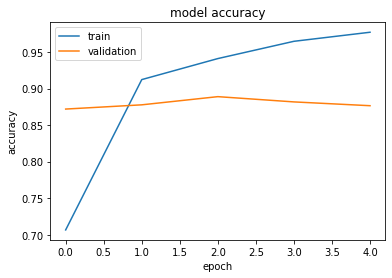

```python
#### Add your code here ####
plt.plot(history.history['accuracy'])
plt.plot(history.history['val_accuracy'])
plt.title('model accuracy')
plt.ylabel('accuracy')
plt.xlabel('epoch')
plt.legend(['train', 'validation'], loc='upper left')
plt.show()
```

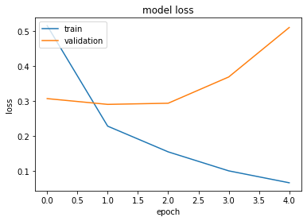

```python
plt.plot(history.history['loss'])
plt.plot(history.history['val_loss'])
plt.title('model loss')
plt.ylabel('loss')
plt.xlabel('epoch')
plt.legend(['train', 'validation'], loc='upper left')
plt.show()
```

##### As can be seen from the graphs above, though the training accuracy and loss shows significant improvements, the validation accuracy starts to decrease and validation loss increases with increasing epochs.

### Predict on one sample (4 Marks)

```python
#### Add your code here ####
predict=model.predict_classes(X_test)
predict_classes=predict.reshape(len(X_test))
```

```python
def get_original_text(i):
    word_to_id = imdb.get_word_index()
    word_to_id = {k:(v) for k,v in word_to_id.items()}
    word_to_id["#"] = 0

    id_to_word = {value:key for key,value in word_to_id.items()}
    return ' '.join(id_to_word[id] for id in X_test[i])
```

```python
SentimentDict={1:'positive', 0:'negative'}
def display_test_sentiment(i):
    print(get_original_text(i))
    print("=======================")
    print('Data Label: ', SentimentDict[y_test[i]])
    print('Predicted Label: ', SentimentDict[predict_classes[i]])
    print("=======================")
    print("=======================")
```

##### Printing the text and pridicting the values of 10 reviews

```python
for i in range(10):
    display_test_sentiment(i)
```

```
# # # # # # # # # # # # # # # # # # # # # # # # # # # # # # # # # # # # # # # # # # # # # # # # # # # # # # # # # # # # # # # # # # # # # # # # # # # # # # # # # # # # # # # # # # # # # # # # # # # # # # # # # # # # # # # # # # # # # # # # # # # # # # # # # # # # # # # # # # # # # # # # # # # # # # …
=======================
Data Label:  negative
Predicted Label:  negative
=======================
=======================
# # # # # # # # # # # # # # # # # # # # # # # # # # # # # # # # # # # # # # # # and and you world's and quite and mankind most and quest are chase and being quickly and little and time hell and plot and and something long put are and every place and consequence and and interplay storytelling being n…
=======================
Data Label:  positive
Predicted Label:  positive
=======================
=======================
grade marc go and and be lot and oliver and and and picture and feel and and ensue like different just clichéd girl at finds and and no and glory any and children's just moment like mixing any and and leaving and and and even cliche and purchased and money easily egypt and glory any and and and and …
=======================
Data Label:  positive
Predicted Label:  positive
=======================
=======================
# # # # # # # # # # # # # # # # # # # # # # # # # # # # # # # # # # # # # # # # # # # # # # # # # # # # # # # # # # # # # # # # # # # # # # # # # # # # # # # # # # # # # # # # # # # # # # # # # # # # # # # # # # # # # # # # # # # # # # # and and stick did and roles and on take and my and although ex…
=======================
Data Label:  negative
Predicted Label:  positive
=======================
=======================
# # # # # # # # # # # # # # # # # # # # # # # # # # # # # # # # # # # # # # # # # # # # # # # # # # # # # # # # # # # # # # # # # # # # # # # # # # # # # # # # # # # # # # # # # # # # # # # # # # # # # # # # # # # # # # # # # # # # # # # # # # # # # # # # # # # # # # # # # # # # # # # # # # # # # # …
=======================
Data Label:  positive
Predicted Label:  positive
=======================
=======================
# # # # # # # # # # # # # # # # # # # # # # # # # # # # # # # # # # # # # # # # # # # # # # # # # # # # # # # # # # # # # # # # # # # # # # # # # # # # # # # # # # # # # # # # # # # # # # # # # # # # # # # # # # # # # # # # # # # # # # # # # # # # # # # # # # # # # # # # # # # # # # # # # # # # # # …
=======================
Data Label:  positive
Predicted Label:  negative
=======================
=======================
while composer and and broken short and and and surely and and and sacrifice and paul earned and rolled and and miserable and and and cop and and and its equal paul and and you and came and an and you guess and and and letting and brazil and and and letting he waiting and thrillers and cares debbie …
=======================
Data Label:  positive
Predicted Label:  positive
=======================
=======================
# # # # # # # # # # # # # # # # # # # # # # # # # # # # # # # # # # # # # # # # # # # # # # # # # # # # # # # # # # # # # # # # # # # # # # # # # # # # # # # # # # # # # # # # # # # # # # # # # # # # # # # # # # # # # # # # # # # # # # # # and and and animation and male and and and and explanation f…
=======================
Data Label:  negative
Predicted Label:  negative
=======================
=======================
# # # # # # # # # # # # # # # # # # # # # # # # # # # # # # # # # # # # # # # # # # # # # # # # # # # # # # # # # # # # # # # # # # # # # # # # # # # # # # # # # # # # # # # # # # # # # # # # # # # # # # # # # # # # # # # # # # # # # # # # # # # # # # # # # # # # # # # # # # # # # # # # # # # # # # …
=======================
Data Label:  negative
Predicted Label:  positive
=======================
=======================
talented last fan or aforementioned and and stevens and and were exaggerated fault and i'd and separate first so mafia and and resulting day original and knowledge and terrible don't soul teacher well at sick they an harry and and wasn't and and his world and stretch and and how you old and and an a…
=======================
Data Label:  positive
Predicted Label:  positive
=======================
=======================
```